# Reproducible Research: Peer Assessment 1

## Loading and preprocessing the data

First we load the dataset activities.

```r
activity <- read.csv("activity.csv", header = T, sep = ",")
str(activity)
```

```
## 'data.frame':    17568 obs. of  3 variables:
##  $ steps   : int  NA NA NA NA NA NA NA NA NA NA ...
##  $ date    : Factor w/ 61 levels "2012-10-01","2012-10-02",..: 1 1 1 1 1 1 1 1 1 1 ...
##  $ interval: int  0 5 10 15 20 25 30 35 40 45 ...
```

## What is mean total number of steps taken per day?

First we prepare the dataset for answering this question.

```r
steps <- aggregate(steps ~ date, data = activity, sum, na.rm = TRUE)
```

Calculate the mean of the total number of steps taken per day.

```r
mean(steps$steps, na.rm = TRUE)
```

```
## [1] 10766.19
```

Calculate the median of the total number of steps taken per day.

```r
median(steps$steps, na.rm = TRUE)
```

```
## [1] 10765
```

Report the total number of steps taken per day.

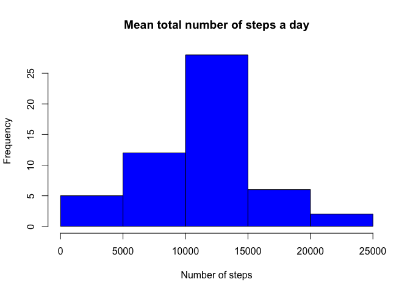

```r
hist(steps$steps,main = "Mean total number of steps a day", xlab = "Number of steps", col = "blue")
```

## What is the average daily activity pattern?

First we prepare the dataset for answering this question.

```r
steps.interval <- tapply(activity$steps, activity$interval, mean, na.rm = T)
```

A time series plot (type = “1”) of the 5-minute interval (x-axis) and the average number of steps taken, averaged across all days (y-axis).

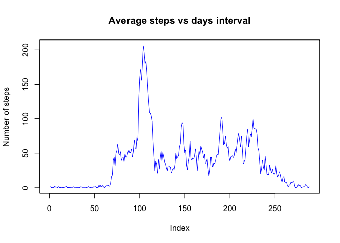

```r
plot(steps.interval, type = "l", main = ("Average steps vs days interval"),
    ylab = "Number of steps", col = "blue")
```

Which 5-minute interval, on average across all the days in the dataset, contains the maximum number of steps?

```r
seq(along = steps.interval)[steps.interval == max(steps.interval)]
```

```
## [1] 104
```